# Working with StarTrek package

Claudia Cava, Isabella Castiglioni

2016-10-13

# Introduction

Motivation: New technologies have made possible to identify marker gene signatures. However, gene expression-based signatures present some limitations because they do not consider metabolic role of the genes and are affected by genetic heterogeneity across patient cohorts. Considering the activity of entire pathways rather than the expression levels of individual genes can be a way to exceed these limits. This tool `StarTrek` presents some methodologies to measure pathway activity and cross-talk among pathways integrating also the information of network and TCGA data. New measures are under development.

# Installation

To install use the code below.

```r
source("https://bioconductor.org/biocLite.R")
biocLite("StarTrek")
```

# `Get data`: Get KEGG pathway, network and TCGA data

## `getKEGGdata`: Searching KEGG data for download

You can easily search KEGG data and their genes using the `getKEGGdata` function. It can download 306 pathways from KEGG or the user can select a particular list of pathways manually curated based on their role in the cell as metabolism, genetic Information processing, environmental information processing, Cellular processes and Organismal Systems using the following parameters:

METABOLISM

- **Carb_met** Carbohydrate_metabolism
- **Ener_met** Energy_metabolism
- **Lip_met** Lipid_metabolism
- **Amn_met** Aminoacid_metabolism
- **Gly_bio_met** Glycan_biosynthesis_and_metabolism
- **Cof_vit_met** Metabolism_of_cofactors_and_vitamins

GENETIC INFORMATION PROCESSING

- **Transcript** Transcription
- **Transl** Translation
- **Fold_degr** Folding_sorting_and_degradation
- **Repl_repair** Replication_and_repair

ENVIRONMENTAL INFORMATION PROCESSING

- **sign_transd** Signal_transduction
- **sign_mol_int** Signaling_molecules_and_interaction

CELLULAR PROCESSES

- **Transp_cat** Transport_and_catabolism
- **cell_grow_d** Cell_growth_and_death
- **cell_comm** Cellular_community

ORGANISMAL SYSTEMS

- **imm_syst** Immune_system
- **end_syst** Endocrine_system
- **circ_syst** Circulatory_system
- **dig_syst** Digestive_system
- **exc_syst** Excretory_system
- **nerv_syst** Nervous_system
- **sens_syst** Sensory_system

The following code is an example to download the pathways involved in Transcription:

```r
path<-getKEGGdata(KEGG_path="Transcript")
```

For example the group Transcript contains different pathways:

List of patwhays for the group Transcript

| RNA polymerase - Homo sapiens (human) |
| --- |
| Basal transcription factors - Homo sapiens (human) |
| Spliceosome - Homo sapiens (human) |

The function `getKEGGdata` with KEGG_path=“KEGG_path” will download all KEGG pathaway.

## `getNETdata`: Searching network data for download

You can easily search human network data from GeneMania using the `getNETdata` function. The network category can be filtered using the following parameters:

- **PHint** Physical_interactions
- **COloc** Co-localization
- **GENint** Genetic_interactions
- **PATH** Pathway
- **SHpd** Shared_protein_domains

For default the organism is homo sapiens. The example show the shared protein domain network for Saccharomyces_cerevisiae. For more information see `SpidermiR` package.

```r
organism="Saccharomyces_cerevisiae"
netw<-getNETdata(network="SHpd",organism)
```

# `Integration data`: Integration between KEGG pathway and network data

## `list_path_net`: List of interacting genes for each pathway (list of genes) according a network type (PHint,COloc,GENint,PATH,SHpd)

The function `list_path_net` creates a list of interacting genes for each pathway. Interacting genes are genes belonging to the same pathway and the interaction is given from network chosen by the user, according the paramenters of the function `getNETdata`. The output will be a list of genes belonging to the same pathway and those having an interaction in the network.

```r
list_path<-list_path_net(net_type=netw,pathway=path)
```

```
## [1] "Basal transcription factors - Homo sapiens (human)"
## [1] "Spliceosome - Homo sapiens (human)"
```

# `Pathway summary indexes`: Score for each pathway

## `average`: Average of genes for each pathway starting from a matrix of gene expression

Starting from a matrix of gene expression (rows are genes and columns are samples, TCGA data) the function `average` creates an average matrix of gene expression for each pathway:

```r
score_mean<-average(dataFilt=tumo[,1:2],pathway=path)
```

## `st_dv`: Standard deviations of genes for each pathway starting from a matrix of gene expression

Starting from a matrix of gene expression (rows are genes and columns are samples, TCGA data) the function `st_dv` creates a standard deviation matrix of gene expression for each pathway:

```r
score_st_dev<-st_dv(dataFilt=tumo[,1:2],pathway=path)
```

```
## [1] "RNA polymerase - Homo sapiens (human)"
## [1] "Basal transcription factors - Homo sapiens (human)"
## [1] "Spliceosome - Homo sapiens (human)"
```

# `Pathway cross-talk indexes`: Score for pairwise pathways

## `euc_dist_crtlk`: Euclidean distance for cross-talk measure

Starting from a matrix of gene expression (rows are genes and columns are samples, TCGA data) the function `euc_dist_crtlk` creates an euclidean distance matrix of gene expression for pairwise pathway.

```r
score_euc_dist<-euc_dist_crtlk(dataFilt=Data_CANCER_normUQ_filt,pathway=path)
```

## `ds_score_crtlk`: Discriminating score for cross-talk measure

Starting from a matrix of gene expression (rows are genes and columns are samples, TCGA data) the function `ds_score_crtlk` creates an discriminating score matrix for pairwise pathway as measure of cross-talk. Discriminating score is given by |M1-M2|/S1+S2 where M1 and M2 are mean and S1 and S2 standard deviation of expression levels of genes in a pathway 1 and and in a pathway 2 .

```r
cross_talk_st_dv<-ds_score_crtlk(dataFilt=tumo[,1:2],pathway=path)
```

```
## [1] "RNA polymerase - Homo sapiens (human)"
## [1] "Basal transcription factors - Homo sapiens (human)"
## [1] "Spliceosome - Homo sapiens (human)"
```

# `Selection of pathway cross-talk`: Selection of pathway cross-talk

## `svm_classification`: SVM classification

Given the substantial difference in the activities of many pathways between two classes (e.g. normal and cancer), we examined the effectiveness to classify the classes based on their pairwise pathway profiles. This function is used to find the interacting pathways that are altered in a particular pathology in terms of Area Under Curve (AUC).AUC was estimated by cross-validation method (k-fold cross-validation, k=10).It randomly selected some fraction of TCGA data (e.g. nf= 60; 60% of original dataset) to form the training set and then assigned the rest of the points to the testing set (40% of original dataset). For each pairwise pathway the user can obtain using the methods mentioned above a score matrix ( e.g.dev_std_crtlk ) and can focus on the pairs of pathways able to differentiate a particular subtype with respect to the normal type.

```r
nf <- 60
res_class<-svm_classification(TCGA_matrix=score_euc_dist,nfs=nf,normal=colnames(norm[,1:12]),tumour=colnames(tumo[,1:12]))
```

```
## [1] "RNApolymerase_Basaltranscriptionfactors"
```

```
## [1] "RNApolymerase_Spliceosome"
## [1] "Basaltranscriptionfactors_Spliceosome"
```

# `plotting_cross_talk`: Plot pathway cross-talk

The function `plotting_cross_talk` creates the input for the visualization using `qgraph` package. This function uses the relationship among genes as correlation (green for positive correlations and red for negative correlations) and the width of the lines indicates the strength of the correlation.

The result from `plotting_cross_talk` is shown below:

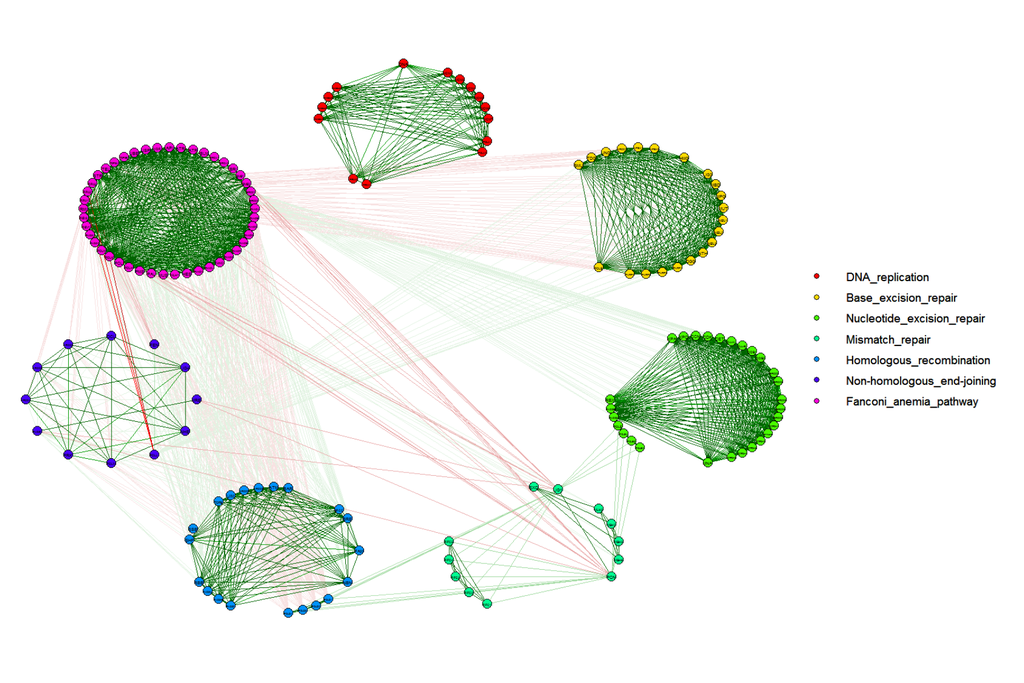